# ProjectPart2

Kaan Kara, Coşkun Uyar, Talha Ünlü, Yusuf Öztürk

4 Aralık 2019

# PROJECT2- Group 8

## Part 1

### a

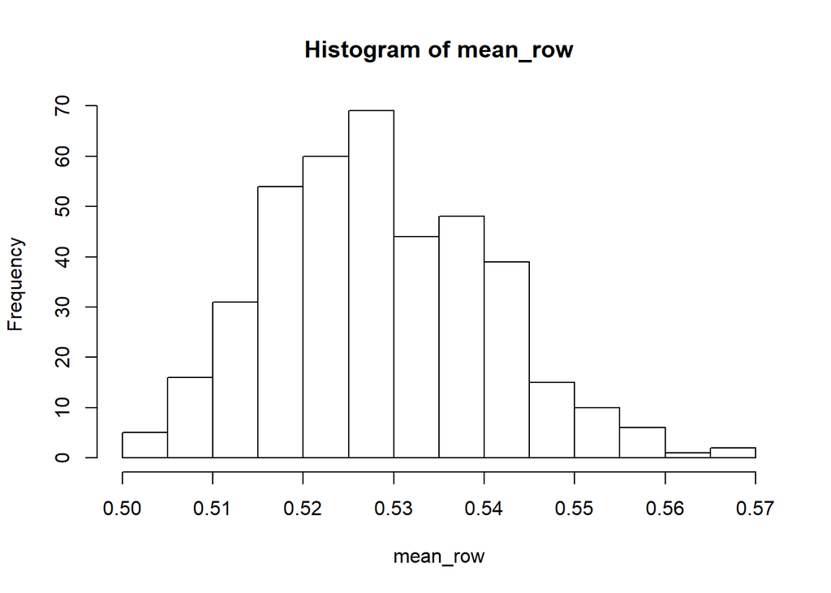

```r
library("jpeg")
library("matrixStats")
img <- readJPEG("C:/Users/kaank/Downloads/part2.jpeg")
mean_row <- rowMeans(img)
hist(mean_row)
```

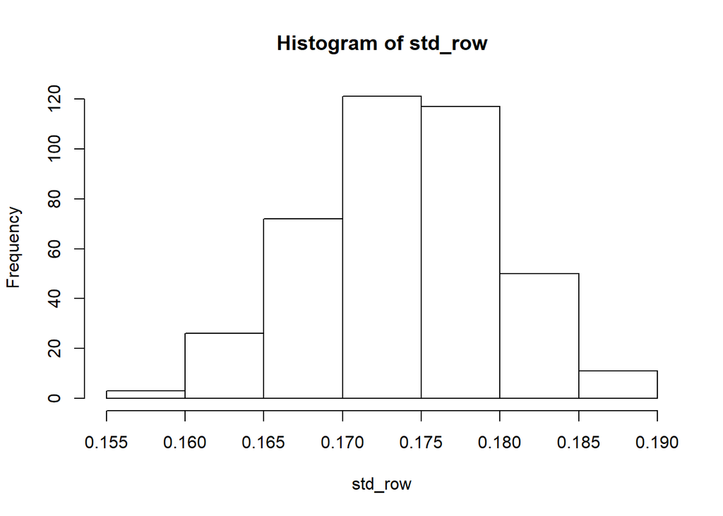

```r
std_row <- rowSds(img)
hist(std_row)
```

After we read the image, we found means and standard deviation of each row.

```r
control_limits_row <- matrix(,400,3)
# control limits is a matrix whose first column is LCL, second column is CL, and 3rd column is UCL
control_limits_row[1:400,1] = mean_row[1:400]-3*std_row[1:400]
control_limits_row[1:400,2] = mean_row[1:400]
control_limits_row[1:400,3] = mean_row[1:400]+3*std_row[1:400]
```

Then we have constructed 400x3 matrix to store LCL, CL, and UCL of every row. Every row of this matrix correspods the control limits of related rows of the image. First, we have used 3 sigma limits to calculate control limits.

```r
imgPart1a <- img
for(i in 1:400){
  for(k in 1:400){
    if(imgPart1a[i,k] < control_limits_row[i,1] | imgPart1a[i,k] > control_limits_row[i,3] ){
      imgPart1a[i,k] = 0;
    }
  }
}
```

According to these control limits, we have eliminated the outlier pixels by converting them to black cells via R code above.

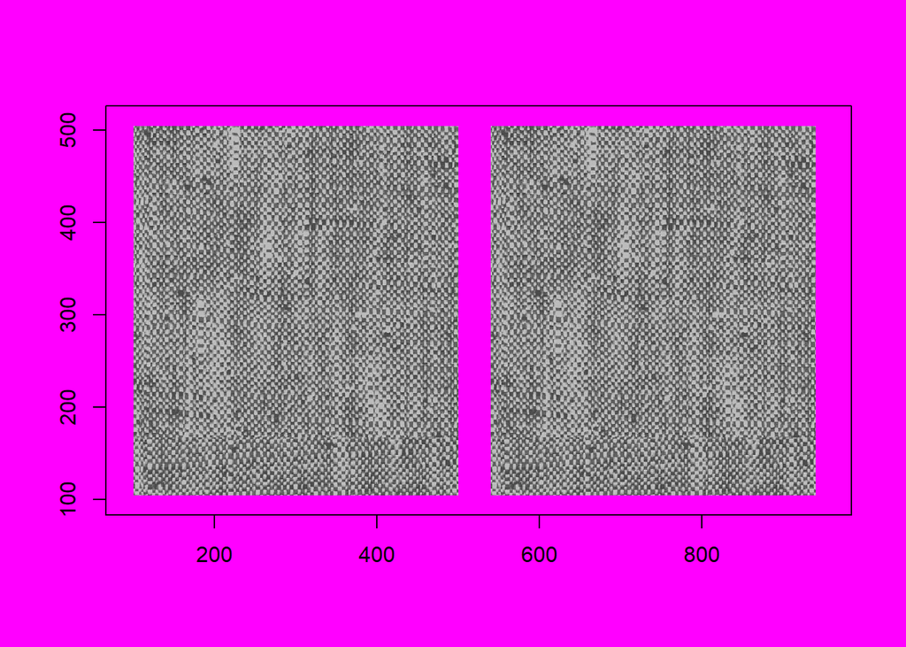

```r
require(grDevices)
op <- par(bg = "magenta")
plot(c(100, 950), c(100, 510), type = "n", xlab = "", ylab = "")
rasterImage(img, 100, 105, 500, 505, interpolate = FALSE)
rasterImage(imgPart1a, 540, 105, 940, 505, interpolate = FALSE)
```

```r
par(op)
```

Then, we have used the R code above to depict original image and manipulated image. As it can be seen, there is no difference with 3 sigma control limits. This can result from the high standard variation at each row. Standard deviation is high because there are basically two types of pixels in our image. Mojarity of the images is either dark or light. These darkness and lightness recur itself by some legs and same hue both horizontally and vertically.

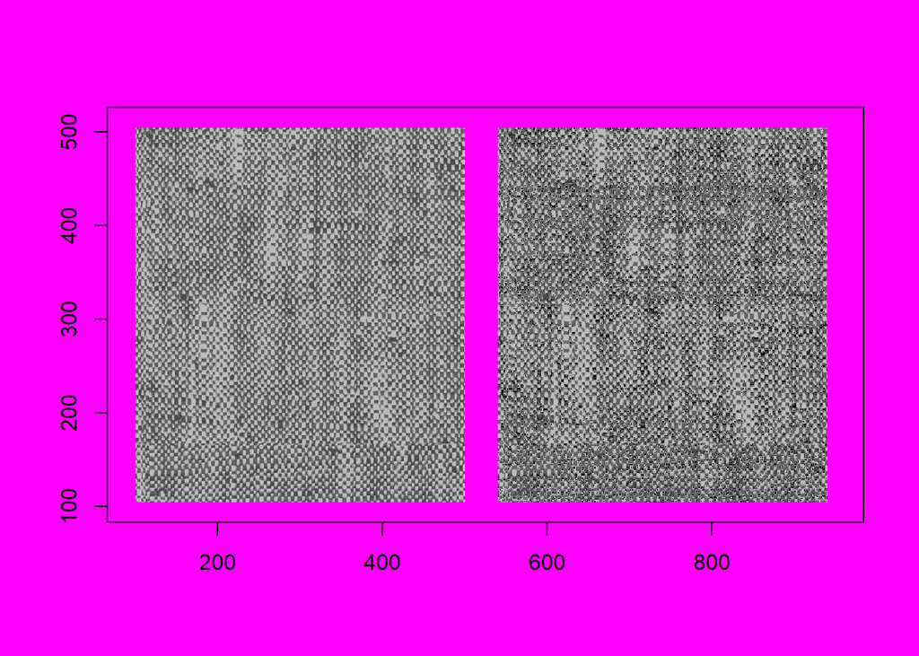

```r
control_limits_row[1:400,1] = mean_row[1:400]-(1.4)*std_row[1:400]
control_limits_row[1:400,2] = mean_row[1:400]
control_limits_row[1:400,3] = mean_row[1:400]+(1.4)*std_row[1:400]


imgPart1a <- img
for(i in 1:400){
  for(k in 1:400){
    if(imgPart1a[i,k] < control_limits_row[i,1] | imgPart1a[i,k] > control_limits_row[i,3] ){
      imgPart1a[i,k] = 0;
    }
  }
}

require(grDevices)
op <- par(bg = "magenta")
plot(c(100, 950), c(100, 510), type = "n", xlab = "", ylab = "")
rasterImage(img, 100, 105, 500, 505, interpolate = FALSE)
rasterImage(imgPart1a, 540, 105, 940, 505, interpolate = FALSE)
```

```r
par(op)
```

In case we have chosen some norrower limit, for example 1.4 sigma, it yields more observable changes in the actual image.

### b

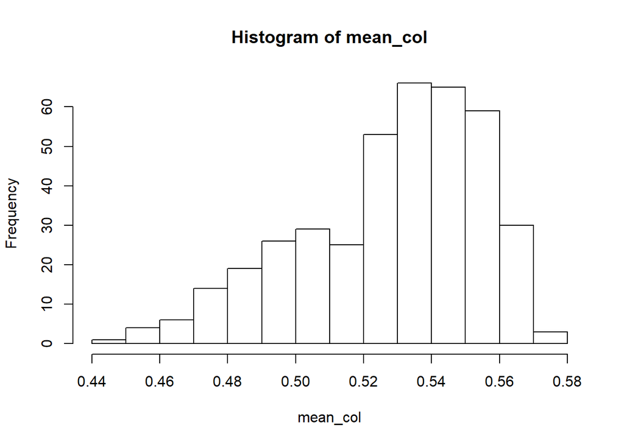

```r
mean_col <- colMeans(img)
hist(mean_col)
```

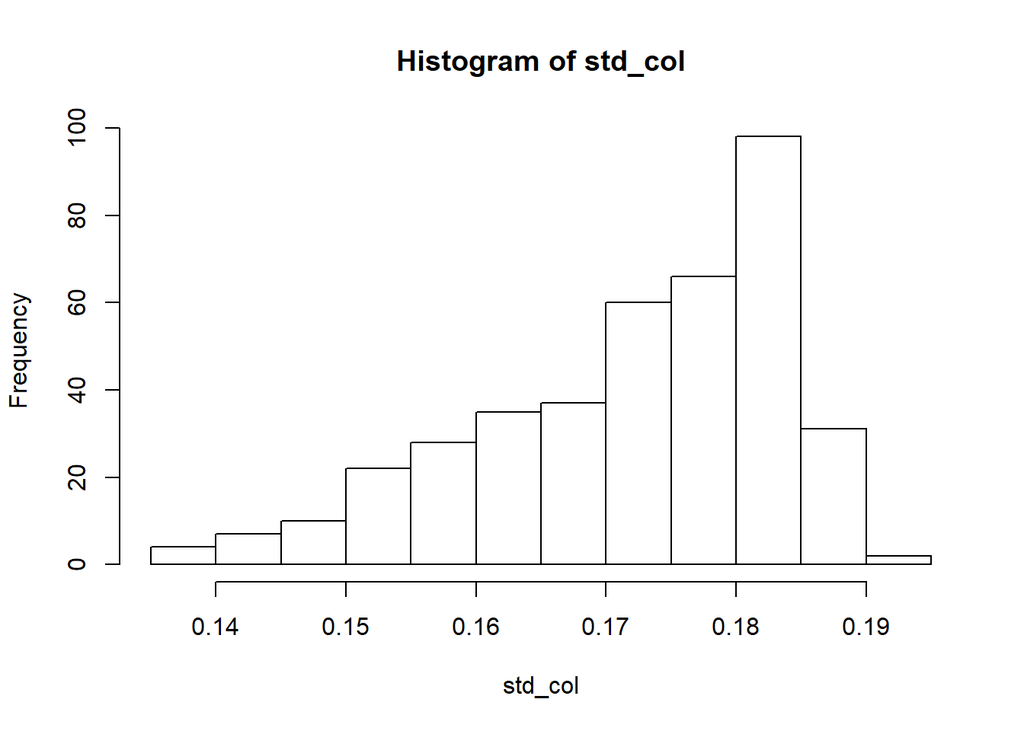

```r
std_col <- colSds(img)
hist(std_col)
```

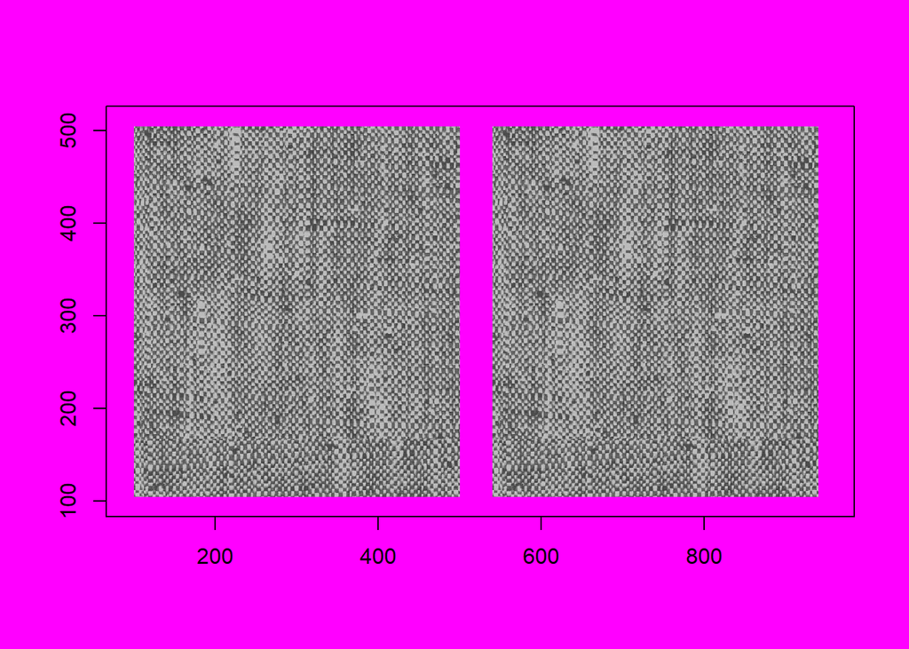

```r
control_limits_col <- matrix(,400,3)

# control limits is a matrix whose first column is LCL, second column is CL, and 3rd column is UCL
control_limits_col[1:400,1] = mean_col[1:400]-3*std_col[1:400]
control_limits_col[1:400,2] = mean_col[1:400]
control_limits_col[1:400,3] = mean_col[1:400]+3*std_col[1:400]

imgPart1b <- img
for(i in 1:400){
  for(k in 1:400){
    if(imgPart1b[i,k] < control_limits_col[i,1] | imgPart1b[i,k] > control_limits_col[i,3] ){
      imgPart1b[i,k] = 0;
    }
  }
}

require(grDevices)
op <- par(bg = "magenta")
plot(c(100, 950), c(100, 510), type = "n", xlab = "", ylab = "")
rasterImage(img, 100, 105, 500, 505, interpolate = FALSE)
rasterImage(imgPart1b, 540, 105, 940, 505, interpolate = FALSE)
```

```r
par(op)
```

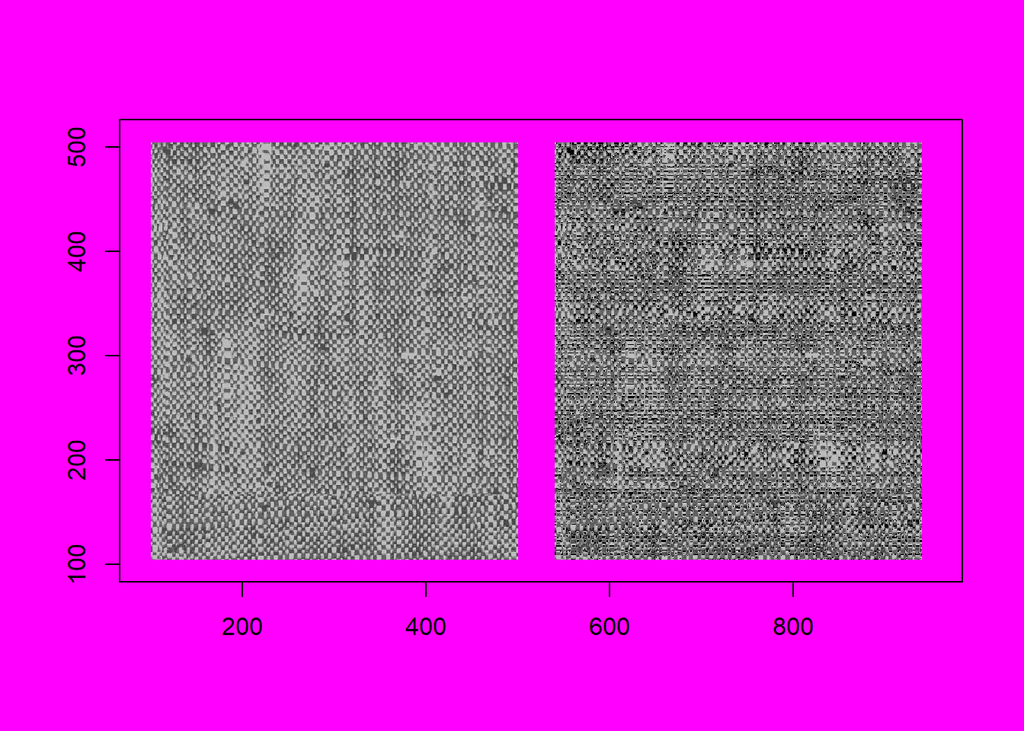

```r
control_limits_col[1:400,1] = mean_col[1:400]-(1.4)*std_col[1:400]
control_limits_col[1:400,2] = mean_col[1:400]
control_limits_col[1:400,3] = mean_col[1:400]+(1.4)*std_col[1:400]

imgPart1b <- img
for(i in 1:400){
  for(k in 1:400){
    if(imgPart1b[i,k] < control_limits_col[i,1] | imgPart1b[i,k] > control_limits_col[i,3] ){
      imgPart1b[i,k] = 0;
    }
  }
}

require(grDevices)
op <- par(bg = "magenta")
plot(c(100, 950), c(100, 510), type = "n", xlab = "", ylab = "")
rasterImage(img, 100, 105, 500, 505, interpolate = FALSE)
rasterImage(imgPart1b, 540, 105, 940, 505, interpolate = FALSE)
```

```r
par(op)
```

```r
library("jpeg")
library("imager")
library("broom")
library("EnvStats")
img <- readJPEG("C:/Users/kaank/Downloads/part2.jpeg")

initial_matrix <- matrix(,2600,4)
colnames(initial_matrix) = c("pxA","pxB","value","num")
prediction_matrix <- matrix(,350,350)
residual_matrix <- matrix(,350,350)
```

In part 2, we have expected to construct a linear model for centers of each 51x51 patch. For this purpose, first we have create a matrix named initial_matrix to store info about the 51x51 patches. It consists 2600 elements which will be used to forecast center value. Columns of this matrix stores, x-coordinates, y-coordinates, pixel value, and representative number. Prediction matrix will store that predicted values for center values by using representative number. It has 350x350 rows and columns because pixels that are close to edges cannot be predicted via 51x51 patches. Lastly, residual matrix will store the difference between predicted and actual values namely residual.

```r
for(a in 1:350){
  for(b in 1:350){
    k <- 1
    for(i in a:(a+50)){
      for(j in b:(b+50)){
        if(i == a+25 & j == b+25){
        }else{
          initial_matrix[k,1] = i
          initial_matrix[k,2] = j
          initial_matrix[k,3] = img[i,j]
          if(k > 1299){
            initial_matrix[k,4] = k+1
          }else{
            initial_matrix[k,4] = k
          }
          k <- k + 1
        }
      }
    }

    initial_matrix_data_frame <- as.data.frame(initial_matrix)
    simple.fit = lm(value~num, data=initial_matrix_data_frame)
    prediction_matrix[a,b]<-predict(simple.fit,data.frame(num=1300))
    residual_matrix[(a),(b)]<- img[a+25,b+25]- predict(simple.fit,data.frame(num=1300))

  }
}
```

Here, we have generated linear models for each patch and predict its value accordind to the linear model that is genared for it. By predicting the values, only 51x51 pixels around it are taken into account. Then, the residal matrix helped us to store the residuals which are the difference between the actual values of the pixel and the prediction via its neighboors.

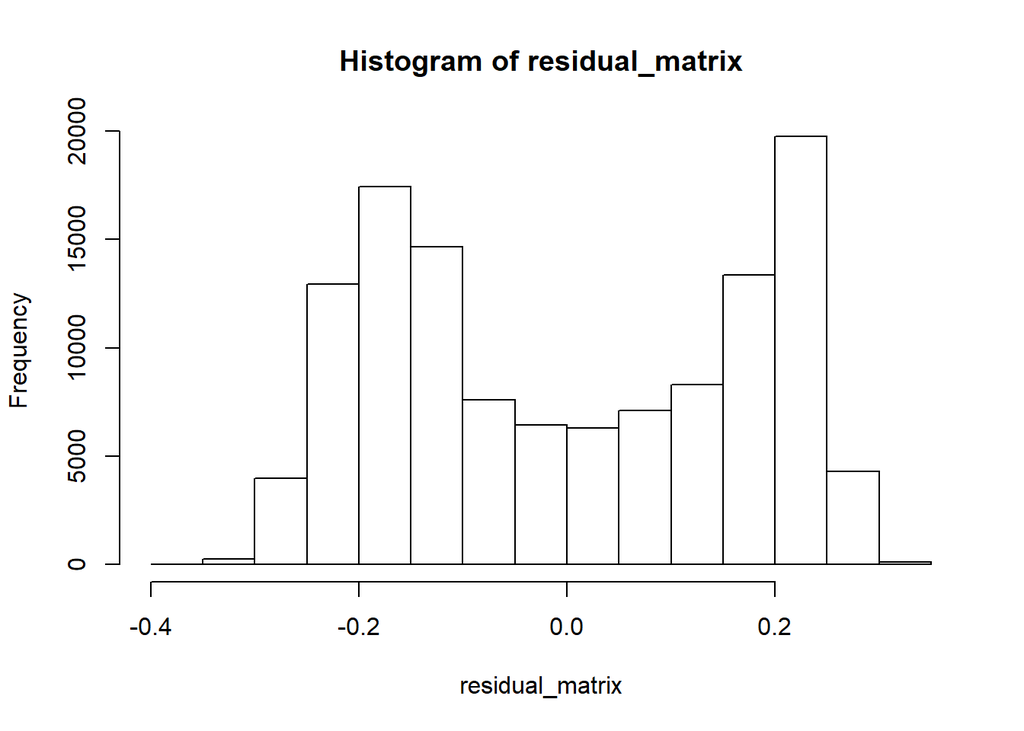

```r
hist(residual_matrix)
```

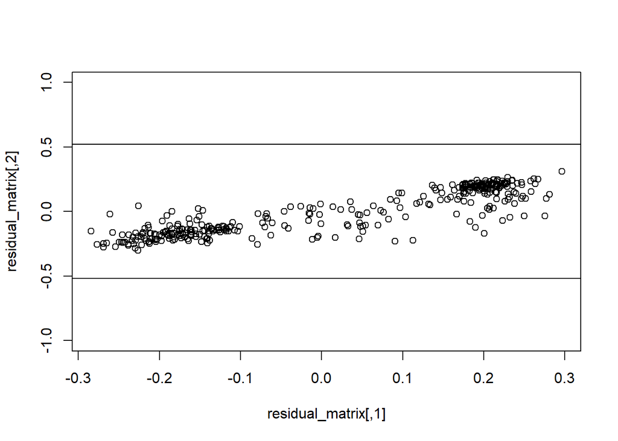

```r
res_mean <- mean(residual_matrix)
res_sd <- sd(residual_matrix)
res_UCL <- res_mean + (3*res_sd)
res_LCL <- res_mean - (3*res_sd)
plot(residual_matrix, ylim=c(-1,1))
abline(h = res_UCL)
abline(h = res_LCL)
```

After we have obtained residual matrix, we used its values to construct control charts on residuals. As we check the histogram of the residuals we can observe that its not distributed normally. The reason can be autocorrelation. In our image some dark and light hues recur itself both horizontally and vertically. There are two polars and regression line tries to find some fit that goes through middle of them. This yields the accumulation on -0,2 and +0,2 values. When we choose 3 sigma control limits, we cannot observe out of control values due to high variance.

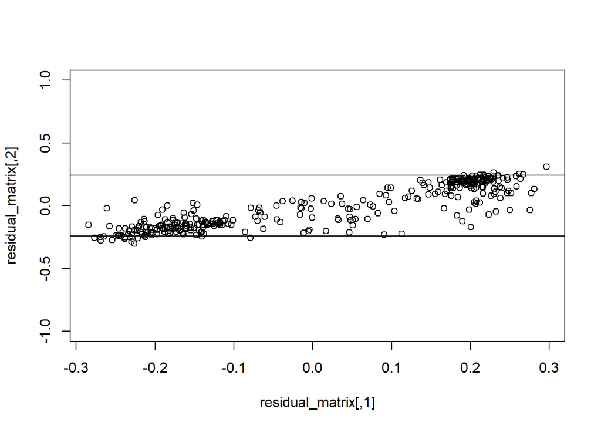

```r
res_mean <- mean(residual_matrix)
res_sd <- sd(residual_matrix)
res_UCL <- res_mean + (1.4*res_sd)
res_LCL <- res_mean - (1.4*res_sd)
plot(residual_matrix, ylim=c(-1,1))
abline(h = res_UCL)
abline(h = res_LCL)
```

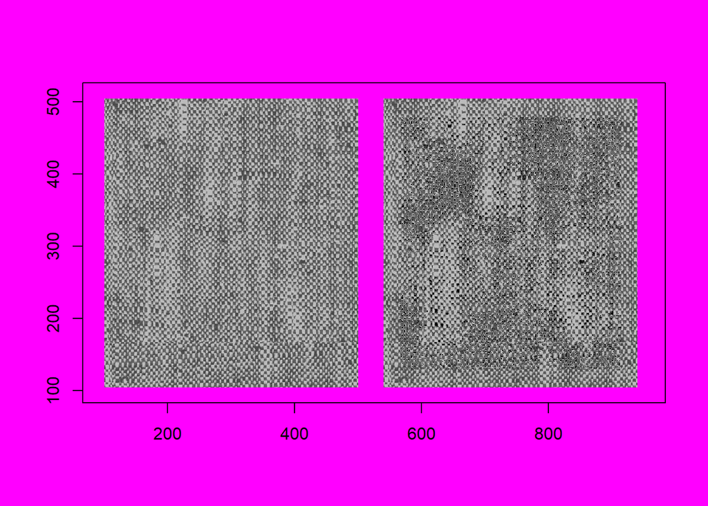

```r
imgPart2 <- img
for(i in 1:350){
  for(k in 1:350){
    if(residual_matrix[i,k] <  res_LCL| residual_matrix[i,k] > res_UCL ){
      imgPart2[(i+25),(k+25)] = 0;
    }
  }
}

require(grDevices)
op <- par(bg = "magenta")
plot(c(100, 950), c(100, 510), type = "n", xlab = "", ylab = "")
rasterImage(img, 100, 105, 500, 505, interpolate = FALSE)
rasterImage(imgPart2, 540, 105, 940, 505, interpolate = FALSE)
```

```r
par(op)
```

Instead of 3, if we choose 1.4 as sigma, we can detect some out of control values and observe some changes in the manipulated version of the actual image. Unfortunately, we can not detect the outliers next to the edges with this method.

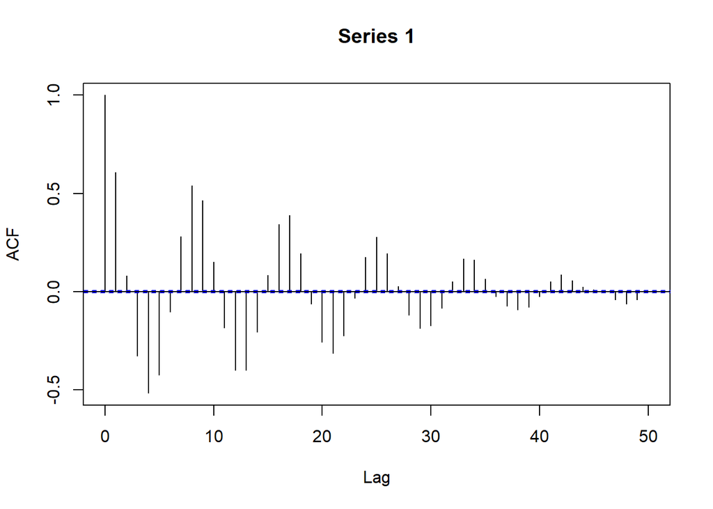

```r
c<-1
acfmatrix<-matrix(,(350*350),1)
for(i in 1:350){
  for(k in 1:350){
    acfmatrix[c,]<-residual_matrix[i,k]
    c<-c+1
  }
}
acf(acfmatrix)
```

To check whether there is autocorrelation in residuals, we have used acf function. As it can clearly seen the acf plot, the pattern recurs it self at every 8 lags and way beyond the blue dashed line. We can conculude that residuals are autocorrelated, which doesnt abide by linear regression requirements.

#### Dealing with Autocorrelation

To handle with this problem we can benefit from time series methodology because there is a need to get rid of autocorrelation and it is not possible with our existing model.Using ARIMA can helps us in terms of eliminating autocorelation by differencing. Any other time series modelling strategy such as EWMA, ARMA, AR can help us in this issue as well.